# Metrics Computation for the Occurrences Cube of the Birds Directive Annex I

Data mobilisation from GBIF to the EBV Data Portal

Lina Estupinan-Suarez, Miguel Fernandez

German Centre for Integrative Biodiversity Research (iDiv)  
lina.estupinans@idiv.de

2024-08-08

[figure not shown]

### Introduction

- Total number of occurrences
- Earliest month with records
- Latest month with records
- Month with the highest number of records
- Month with the second highest number of records
- Month with the third highest number of records

*Note: This series of notebooks is part of the results of Task 3.3 of the [Biodiversity Building Blocks for Policy](https://b-cubed.eu/) Project funded by the European Union’s Horizon Europe Research and Innovation Programme (ID No 101059592). Additional notebooks exploring the results and calculating simple metrics are also available in the same repository.*

### Load Library and Input Data

We start by loading all the libraries needed in this notebook.

```r
rm(list=ls())
gc()
```

```
         used (Mb) gc trigger (Mb) max used (Mb)
Ncells 530916 28.4    1187915 63.5   657974 35.2
Vcells 973524  7.5    8388608 64.0  1768178 13.5
```

```r
# Load requiered libraries
library(b3gbi) # for csv occurrence cubes
library(purrr) # for data summary and grouping
library(here)
library(dplyr)
library(lubridate) # for dates
library(terra) # for raster
library(ncdf4)
library(ggplot2)
library(sf)
library(stringr)
library(viridis)
```

Now we load all input data obtained in the previous notebooks. These are:

- The occurrence cube of the Birds Directive Annex I obtained previously through GBIF API.
- Inputs related to the EEA grid at 10 km for rasterisation.
- Taxonomic information of all analysed species.

```r
occcube <- "0044085-240626123714530"

# Load occurrence cube using b3gbi
cin <- process_cube(here(paste0("output/datacubes/csv/birds/", occcube,".csv")))

# Import the taxonomy of all species listed in the Birds Directive Annex 1 based on gbif backbone taxonomy
gbif_tax <- read.csv(here("input/data/birds/taxonomy/list193birds_directive_annexi_allaccepted_usagekey_gbif.csv"))

# Load precomputed centroids for EEA 10 km grid
coorin <- read.csv(here("input/grid/centroids/eeagrid_centroids_10K.csv"))

# Import and convert the EU borders to a data frame
borders_eu <- st_read("C:/data/grid/eea_v_3035_100_k_adm-boundaries-eea38-plus_i_2018-2020_v01_r00/NUTS2021_3035.shp")
# Load reference EEA grid in raster format
gridin <- rast(here("input/grid/eeagrid_10K.tif"))
res <- res(gridin)[1] #resolution of reference raster

# Replace by corresponding column name of input dataset
colnames(coorin)[colnames(coorin) == "eeacellcode"] <- "cellCode"
```

```r
# Find number of species
spskey <- unique(cin[["data"]][["taxonKey"]]) # Check wether to use "taxonKey" or "acceptedUsageKey"
```

### Metrics Computation

#### **Metric 1:** Total Number of Occurrences

We calculate the total number of occurrences for each species using the function `total_occ`.

```r
# Calculate total number of occurrences per pixel
total_occ <- function(cin, gridin, coorin){

  # Find number of species
  spskey <- unique(cin[["data"]][["taxonKey"]])

  # Create empty raster
  r <- rast(ext(gridin), resolution=res(gridin), nlyrs=length(spskey), crs=crs(gridin))
  values(r) <- NA

   for (i in 1:50){ # length(spskey)
  print(i)
    # Subset one species
    spsi <- cin[["data"]][cin[["data"]]$taxonKey == spskey[i], ]

    # sum up the total number of occurrences per cellCode
    metricx <- spsi %>%
      group_by(cellCode) %>%
       summarize(total_occurrences = sum(obs), cellCode = first(cellCode))

    # Merge pixel coordinates with the corresponing EEA grid ID
    metriccoor <- merge(metricx[,c("total_occurrences", "cellCode")], coorin, by="cellCode")

    print(length(unique(metriccoor$x)))

    # Check for a few occurrences. Only 1 occurrence cannot be rasterised, and error extente when they are very few.
    if(length(unique(metriccoor$x)) < 10){
      # Add second empty point
      x <- metriccoor$x[1] + res
      y <- metriccoor$y[1] + res
      metriccoor <- rbind(metriccoor, c(NA, NA ,NA, x, y))
    }

  # Rasterize data
  r[[i]]  <- rast(metriccoor[,c("x", "y", "total_occurrences")], type="xyz", crs=crs(gridin), extent=ext(gridin))
    }

  # Assign name of species key to the corresponding raster 'layer'
  names(r) <- spskey

  return(r)
}
```

The next step is to run the previous funcion and plot an example.

```r
total_occ_sps <- total_occ(cin, gridin, coorin)
```

```
|---------|---------|---------|---------|=========================================                                          [1] 1
[1] 402
[1] 2
[1] 427
[1] 3
[1] 445
[1] 4
[1] 439
[1] 5
[1] 414
[1] 6
[1] 380
[1] 7
[1] 336
[1] 8
```

[output cut: 85 more lines]

Prepare data for plotting

```r
# Select one specie
spi <- 24


# Convert data to a data frame
df <- as.data.frame(total_occ_sps[[spi]], xy=TRUE)
spid <- as.numeric(colnames(df)[3])
colnames(df)[colnames(df) == colnames(df)[3]] <- "Value"

# Find the specie scientific name
spi_name <- gbif_tax %>%
  filter(key %in% spid)
```

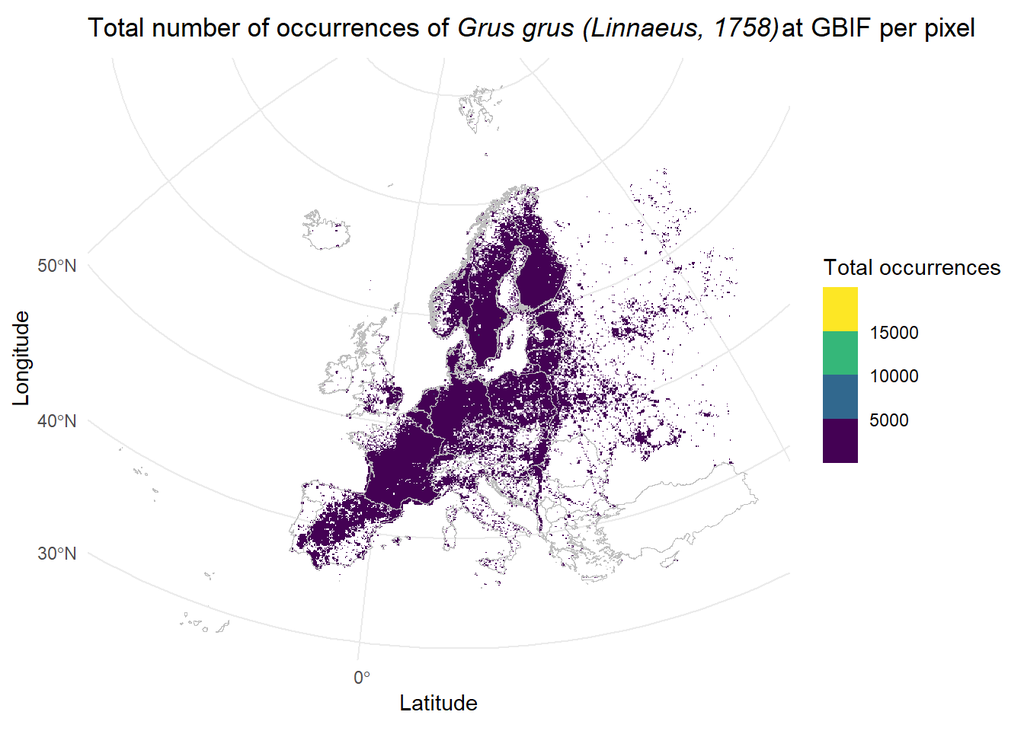

```r
ggplot() +
  geom_raster(data = df, aes(x = x, y = y, fill = Value)) + # Use alpha for transparency
  geom_sf(data = borders_eu, fill = NA, color = "gray") +
  scale_fill_binned(name="Total occurrences", type = "viridis") + # Optional: for better color scale
  theme_minimal() +
  labs(
    title = bquote("Total number of occurrences of " * italic(.(spi_name$scientificName)) * "at GBIF per pixel"),
    x = "Latitude",
    y = "Longitude",
    fill = "Total <br> occurrences")
```

#### **Metric 2 and 3:** Earliest and Latest Month of Occurrence at GBIF

We calculate the earliest (latest) month of occurrence for each species. The function `min_max_month` finds the earliest (or latest) month of records per species at the pixel level across the entire dataset.

```r
min_max_month <- function(cin, gridin, coorin){
  # Find number of species
  spskey <- unique(cin[["data"]][["taxonKey"]])

  # Create empty raster for metric 2
  rmin <- rast(ext(gridin), resolution=res(gridin), nlyrs=length(spskey), crs=crs(gridin))
  values(rmin) <- NA

  # Create empty raster for metric 3
  rmax <- rast(ext(gridin), resolution=res(gridin), nlyrs=length(spskey), crs=crs(gridin))
  values(rmax) <- NA


  for (i in 20:50){  # length(spskey)
  print(i)
  # Subset one species
  spsi <- cin[["data"]][cin[["data"]]$taxonKey == spskey[i], ]

  # Convert date from character to numeric
  todates <- as.data.frame(str_split(spsi$yearMonth, "-", simplify = TRUE))
  colnames(todates) <- c("year", "month")

# Add year and month columns separate to the initial data
spsi$year <- todates$year
spsi$month <- todates$month

 # Calculate metric 2. In this example earliest month of record
    metric_min <- spsi %>%
      group_by(cellCode) %>%
      slice_min(month, with_ties = FALSE) %>%
      ungroup()

# Calculate metric 3. In this example earliest month of record
    metric_max <- spsi %>%
      group_by(cellCode) %>%
      slice_max(month, with_ties = FALSE) %>%
      ungroup()

  metricx_coor <- function(metricx, coorin, res){

    # Merge pixel coordinates with the corresponing EEA grid ID
    metriccoorx <- merge(metricx[,c("month", "cellCode")], coorin, by="cellCode")
    print(length(unique(metriccoorx$x)))

    if(length(unique(metriccoorx$x)) < 10){
      #add second empty point
      x <- metriccoorx$x[1] + res
      y <- metriccoorx$y[1] + res
      metriccoorx <- rbind(metriccoorx, c(NA, NA ,NA, x, y))
    }
    return(metriccoorx)
  }
  metriccoor_min <- metricx_coor(metric_min, coorin, res)
  metriccoor_max <- metricx_coor(metric_max, coorin, res)

  # Rasterize data
  rmin[[i]]  <- rast(metriccoor_min[,c("x", "y", "month")], type="xyz", crs=crs(gridin), extent=ext(gridin))

  # Rasterize data
  rmax[[i]]  <- rast(metriccoor_max[,c("x", "y", "month")], type="xyz", crs=crs(gridin), extent=ext(gridin))

  }

  # Assign name of species key to the corresponding raster 'layer'
  names(rmin) <- spskey
  names(rmax) <- spskey


  results_list <- list(earliest_month = rmin, latest_month = rmax)
  return(results_list)

}
```

In the following code chunk, we compute metrics 2 and 3.

```r
earliest_latest_months <- min_max_month(cin, gridin, coorin)
```

```
|---------|---------|---------|---------|=========================================                                          |---------|---------|---------|---------|=========================================                                          [1] 20
[1] 284
[1] 284
[1] 21
[1] 446
[1] 446
[1] 22
[1] 402
[1] 402
[1] 23
[1] 402
[1] 402
[1] 24
[1] 446
[1] 446
```

[output cut: 78 more lines]

Note that the min_max_month function returns a list. The first element of the list is a raster containing the earliest month of the records. The second element is a raster containg the latest month of records.

```r
# Extract raster of earliest month of records
earliest_month <- earliest_latest_months[[1]]

# Extract raster of latest month of records
latest_month <- earliest_latest_months[[2]]
```

Prepare data for plotting.

```r
# Convert raster layers to data frames
spi <- 24
df1 <- as.data.frame(earliest_month[[spi]], xy=TRUE)
spid <- as.numeric(colnames(df1)[3])
colnames(df1)[colnames(df1) == colnames(df1)[3]] <- "Value"
df1[["Value"]] <- df1[["Value"]]

df2 <- as.data.frame(latest_month[[spi]], xy=TRUE)
colnames(df2)[colnames(df2) == colnames(df2)[3]] <- "Value"
df2[["Value"]] <- df2[["Value"]]

# Find the specie scientific name
spi_name <- gbif_tax %>%
  filter(key %in% spid)
```

This code chunk is for plotting the ‘Earliest month of Records at GBIF’ for one species.

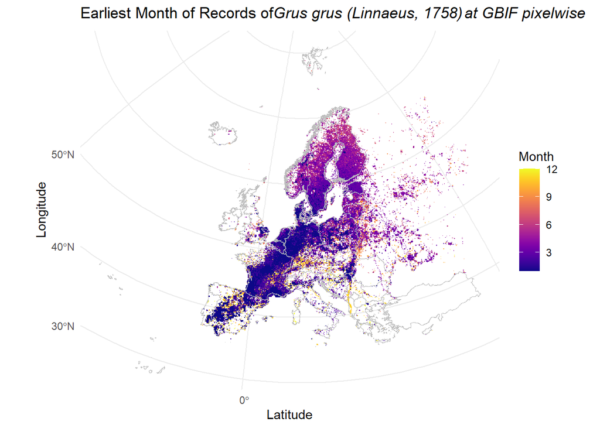

```r
ggplot() +
  geom_raster(data = df1, aes(x = x, y = y, fill = Value)) + # Use alpha for transparency
  geom_sf(data = borders_eu, fill = NA, color = "gray") +
  # scale_fill_distiller(name="Month", palette = "Spectral", breaks = c(1, 3, 6, 9, 12)) + # Optional: for better color scale
  scale_fill_viridis(name="Month", option = "C", direction = 1) + #
  theme_minimal() +
  labs(
    title = bquote("Earliest Month of Records of" * italic(.(spi_name$scientificName) * "at GBIF pixelwise")),
    x = "Latitude",
    y = "Longitude",
    fill = "Month")
```

And the following code chunck is for plotting the “Latest date of records at GBIF” for the same specie.

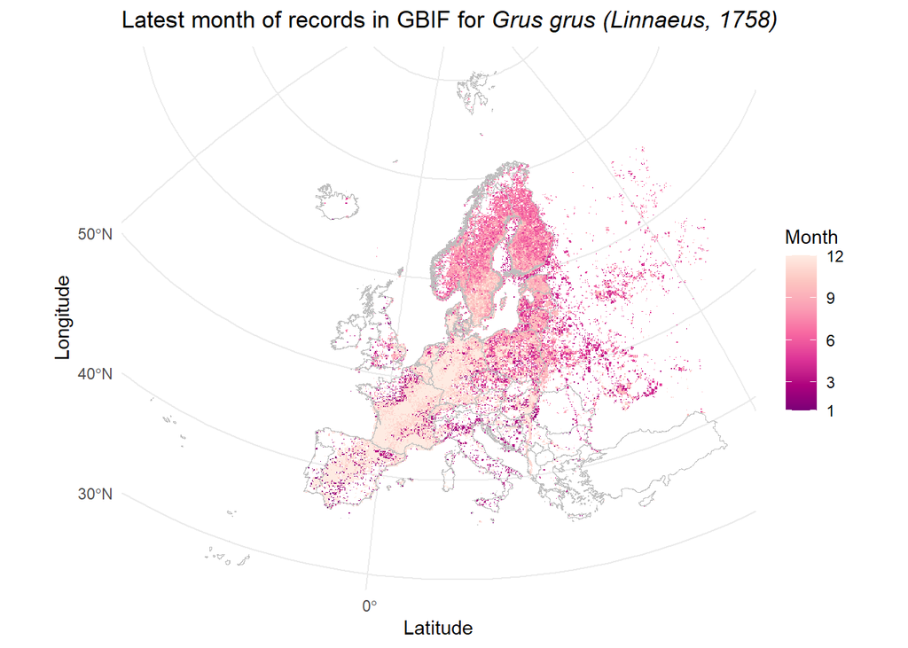

```r
ggplot() +
  geom_raster(data = df2, aes(x = x, y = y, fill = Value)) + # Use alpha for transparency
  geom_sf(data = borders_eu, fill = NA, color = "gray") +
  scale_fill_distiller(name="Month", palette="RdPu", breaks = c(1, 3, 6, 9, 12)) + # Optional: for better color scale
  theme_minimal() +
  labs(
    title = bquote("Latest month of records in GBIF for " * italic(.(spi_name$scientificName))),
    x = "Latitude",
    y = "Longitude",
    fill = "Month")
```

```r
maxrec_month123 <- function(cin, gridin, coorin){
  # Find number of species
  spskey <- unique(cin[["data"]][["taxonKey"]])

  # Create empty raster for metric 3
  r1 <- rast(ext(gridin), resolution=res(gridin), nlyrs=length(spskey), crs=crs(gridin))
  values(r1) <- NA

  # Create empty raster for metric 4
  r2 <- rast(ext(gridin), resolution=res(gridin), nlyrs=length(spskey), crs=crs(gridin))
  values(r2) <- NA

  # Create empty raster for metric 5
  r3 <- rast(ext(gridin), resolution=res(gridin), nlyrs=length(spskey), crs=crs(gridin))
  values(r3) <- NA

  i <- 1

  for (i in 1:30){  # length(spskey)
  print(i)
  # Subset one species
  spsi <- cin[["data"]][cin[["data"]]$taxonKey == spskey[i], ]

  # Convert date from character to numeric
  todates <- as.data.frame(str_split(spsi$yearMonth, "-", simplify = TRUE))
  colnames(todates) <- c("year", "month")

  # Add year and month columns separate to the initial data
  spsi$year <- todates$year
  spsi$month <- todates$month

  # Aggregate occurrences by cell and month
  month_occ <- spsi %>%
      group_by(cellCode, month) %>%
      summarize(total_occurrences = sum(obs), cellCode = first(cellCode))
      # ungroup()

 # Calculate metric 4. In this example earliest month of record
  metric4 <- month_occ %>%
      group_by(cellCode) %>%
      slice_max(total_occurrences, with_ties = FALSE) %>%
      ungroup()

  metricx_coor <- function(metricx, coorin, res){

    # Merge pixel coordinates with the corresponing EEA grid ID
    metriccoorx <- merge(metricx[,c("month", "cellCode")], coorin, by="cellCode")
    print(length(unique(metriccoorx$x)))

    if(length(unique(metriccoorx$x)) < 10){
      #add second empty point
      x <- metriccoorx$x[1] + res
      y <- metriccoorx$y[1] + res
      metriccoorx <- rbind(metriccoorx, c(NA, NA ,NA, x, y))
    }
    return(metriccoorx)
  }

  metric4_coor <- metricx_coor(metric4, coorin, res)
  # metric5_coor <- metricx_coor(metric5, coorin, res)
  # metric5_coor <- metricx_coor(metric6, coorin, res)

  # Rasterize data
  r1[[i]]  <- rast(metric4_coor[,c("x", "y", "month")], type="xyz", crs=crs(gridin), extent=ext(gridin))

  # Rasterize data
  # r2[[i]]  <- rast(metric5_coor[,c("x", "y", "month")], type="xyz", crs=crs(gridin), extent=ext(gridin))

  }

  # Assign name of species key to the corresponding raster 'layer'
  names(r1) <- spskey
  names(r2) <- spskey
  names(r3) <- spskey


  results_list <- list(month_with_highest_records = r1, month_with_2ndhighest_records = r2, month_with_3rdhighest_records = r3)
  return(results_list)

}
```

```r
# Calculate metrics 4, 5 and 6
months_high_rec <- maxrec_month123(cin, gridin, coorin)
```

```
|---------|---------|---------|---------|=========================================                                          |---------|---------|---------|---------|=========================================                                          |---------|---------|---------|---------|===========…
[1] 402
[1] 2
[1] 427
[1] 3
[1] 445
[1] 4
[1] 439
[1] 5
[1] 414
[1] 6
[1] 380
[1] 7
[1] 336
[1] 8
```

[output cut: 45 more lines]

```r
# Calculate metrics 4, 5 and 6
month_1sthigh <- months_high_rec[[1]]
# months_2ndthigh <- months_high_rec[[2]]
# months_3rdthigh <- months_high_rec[[3]]
```

```r
# Convert raster layers to data frames
spi <- 20
df1 <- as.data.frame(month_1sthigh[[spi]], xy=TRUE)
spid <- as.numeric(colnames(df1)[3])
colnames(df1)[colnames(df1) == colnames(df1)[3]] <- "Value"
df1[["Value"]] <- df1[["Value"]]

# df2 <- as.data.frame(latest_month[[spi]], xy=TRUE)
# colnames(df2)[colnames(df2) == colnames(df2)[3]] <- "Value"
# df2[["Value"]] <- df2[["Value"]]

# Find the specie scientific name
spi_name <- gbif_tax %>%
  filter(key %in% spid)
```

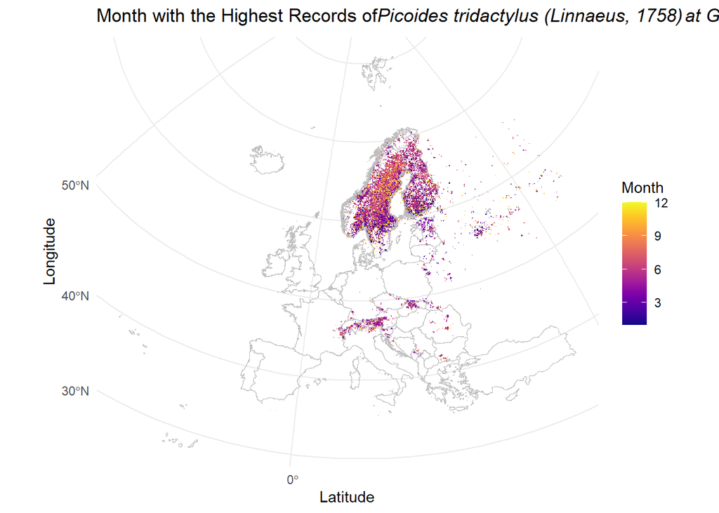

```r
ggplot() +
  geom_raster(data = df1, aes(x = x, y = y, fill = Value)) + # Use alpha for transparency
  geom_sf(data = borders_eu, fill = NA, color = "gray") +
  # scale_fill_distiller(name="Month", palette = "Spectral", breaks = c(1, 3, 6, 9, 12)) + # Optional: for better color scale
  scale_fill_viridis(name="Month", option = "C", direction = 1) + #
  theme_minimal() +
  labs(
    title = bquote("Month with the Highest Records of" * italic(.(spi_name$scientificName) * "at GBIF pixelwise")),
    x = "Latitude",
    y = "Longitude",
    fill = "Month")
```

### Saving data sets as individual tiffs

```r
# writeRaster(total_occ_sps, here("output/datacubes/tif_metrics/birds/01_birds_total_occurrences.tif"), datatype = 'INT4U', overwrite = TRUE)
# writeRaster(min_dates, here("output/datacubes/tif_metrics/birds/02_ias_earliest_date_records.tif"), datatype = 'INT4U', overwrite = TRUE)
# writeRaster(max_dates, here("output/datacubes/tif_metrics/birds/03_ias_latest_date_records.tif"), datatype = 'INT4U', overwrite = TRUE)
# writeRaster(min_dates_datasource, here("output/datacubes/tif_metrics/birds/04_ias_earliest_date_records_sourceofrecord.tif"), datatype = 'INT4U', overwrite = TRUE)
# writeRaster(max_dates_datasource, here("output/datacubes/tif_metrics/birds/05_ias_latest_date_records_sourceofrecord.tif"), datatype = 'INT4U', overwrite = TRUE)
```

#### Prepare taxonomy for the EBV Data Portal

```r
# Filter taxonomy file for only species with data
# Import file for all IAS taxonomy and following the ebvcube format
# tax <- read.csv(here("input/data/ias/taxonomy/List87IAS_EU_match_gbif_synonyms_ebvcube.csv"))

# Subset only for species with data occurrences in GBIF
# gbif_spx <- gbif_tax %>%
#   filter(key %in% spskey)

# Sort the right taxonomic order for filling the EBV Data Portal requierement before saving
# gbif_spx2 <- gbif_spx[,c("kingdom", "phylum", "class", "order", "family", "genus", "species", "key")]

# write.csv(gbif_spx2, here("input/data/ias/taxonomy/List77IAS_EU_gbif_accepted_ebvcube+key.csv"))
```